# Final Project

Puneeth Velivela

2023-12-07

```r
#adding all required packages
library(ggplot2)
library(tidyverse)
library("reshape2")
library(nnet)
library(tree)
library(rpart)
library(rattle)
library(caret)
getwd()
```

```
## [1] "D:/MS/GMU/STAT-515/WD/ProjectAssignment"
```

```r
diabetes <- read.csv("D:/MS/GMU/STAT-515/WD/ProjectAssignment/Dataset.csv")
head(diabetes)
```

```
##   ID No_Pation Gender AGE Urea  Cr HbA1c Chol  TG HDL LDL VLDL  BMI CLASS
## 1  1     34325      M  58 20.8 800   9.1  6.6 2.9 1.1 4.3  1.3 33.0     Y
## 2  1     34325      M  56 20.8 800   9.0  4.6 2.0 1.2 2.5  0.9 35.0     Y
## 3  2     44835      M  60  2.1  56   7.6  3.3 1.7 0.9 1.7  0.8 36.6     Y
## 4  2     44835      M  60  2.1  56   7.2  6.3 3.7 1.0 3.7  1.7 28.0     Y
## 5  3     23972      F  56  4.0  45   9.2  4.1 0.6 1.3 1.4  0.9 30.0     Y
## 6  3     41248      M  53  4.2  55   8.0  5.0 2.5 1.3 2.3  1.6 30.0     Y
```

```r
str(diabetes)
```

```
## 'data.frame':    1000 obs. of  14 variables:
##  $ ID       : int  1 1 2 2 3 3 4 4 5 5 ...
##  $ No_Pation: int  34325 34325 44835 44835 23972 41248 34301 18642 35150 51477 ...
##  $ Gender   : chr  "M" "M" "M" "M" ...
##  $ AGE      : int  58 56 60 60 56 53 43 55 63 58 ...
##  $ Urea     : num  20.8 20.8 2.1 2.1 4 4.2 2.1 9.2 7 5.9 ...
##  $ Cr       : int  800 800 56 56 45 55 55 101 84 67 ...
##  $ HbA1c    : num  9.1 9 7.6 7.2 9.2 8 5.7 8.5 8.1 9.9 ...
##  $ Chol     : num  6.6 4.6 3.3 6.3 4.1 5 4.7 5.6 6 5.2 ...
##  $ TG       : num  2.9 2 1.7 3.7 0.6 2.5 5.3 1.9 2.2 1.8 ...
##  $ HDL      : num  1.1 1.2 0.9 1 1.3 1.3 0.9 1.3 1.1 0.9 ...
##  $ LDL      : num  4.3 2.5 1.7 3.7 1.4 2.3 1.7 1.2 4 3.6 ...
##  $ VLDL     : num  1.3 0.9 0.8 1.7 0.9 1.6 2.4 0.7 1 0.6 ...
##  $ BMI      : num  33 35 36.6 28 30 30 25 28 28 29 ...
##  $ CLASS    : chr  "Y" "Y" "Y" "Y" ...
```

Now Let’s clean the dataset. check for null values

```r
diabetes=na.omit(diabetes)
#Remove unnecessary columns like id patient number and id
diabetes <- diabetes[, c("AGE", "Gender", "Urea", "Cr", "HbA1c", "Chol", "TG", "HDL", "LDL", "VLDL", "BMI", "CLASS")]
summary(diabetes)
```

```
##       AGE           Gender               Urea              Cr
##  Min.   :20.00   Length:1000        Min.   : 0.500   Min.   :  6.00
##  1st Qu.:51.00   Class :character   1st Qu.: 3.700   1st Qu.: 48.00
##  Median :55.00   Mode  :character   Median : 4.600   Median : 60.00
##  Mean   :53.53                      Mean   : 5.125   Mean   : 68.94
##  3rd Qu.:59.00                      3rd Qu.: 5.700   3rd Qu.: 73.00
##  Max.   :79.00                      Max.   :38.900   Max.   :800.00
##      HbA1c             Chol              TG             HDL
##  Min.   : 0.900   Min.   : 0.000   Min.   : 0.30   Min.   :0.200
##  1st Qu.: 6.500   1st Qu.: 4.000   1st Qu.: 1.50   1st Qu.:0.900
##  Median : 8.000   Median : 4.800   Median : 2.00   Median :1.100
##  Mean   : 8.281   Mean   : 4.863   Mean   : 2.35   Mean   :1.205
##  3rd Qu.:10.200   3rd Qu.: 5.600   3rd Qu.: 2.90   3rd Qu.:1.300
##  Max.   :16.000   Max.   :10.300   Max.   :13.80   Max.   :9.900
##       LDL            VLDL             BMI           CLASS
##  Min.   :0.30   Min.   : 0.100   Min.   :19.00   Length:1000
##  1st Qu.:1.80   1st Qu.: 0.700   1st Qu.:26.00   Class :character
##  Median :2.50   Median : 0.900   Median :30.00   Mode  :character
##  Mean   :2.61   Mean   : 1.855   Mean   :29.58
##  3rd Qu.:3.30   3rd Qu.: 1.500   3rd Qu.:33.00
##  Max.   :9.90   Max.   :35.000   Max.   :47.75
```

```r
table(diabetes$CLASS)
```

```
##
##   N  N    P   Y  Y
## 102   1  53 840   4
```

```r
table(diabetes$Gender)
```

```
##
##   f   F   M
##   1 434 565
```

```r
diabetes$Gender <- ifelse(diabetes$Gender == "f", "F", diabetes$Gender)
diabetes$Gender <- as.numeric(factor(diabetes$Gender))
# normalizing gender values between 0 and 1 (0 for F and 1 for M)
diabetes$Gender <- diabetes$Gender-1
#remove spaces in CLASS variable
diabetes$CLASS <- trimws(diabetes$CLASS)
table(diabetes$CLASS)
```

```
##
##   N   P   Y
## 103  53 844
```

```r
#convert CLASS variable to factor variable
diabetes$CLASS=as.factor(diabetes$CLASS)
```

Now lets do some visualizations on the dataset with respect to the class variable

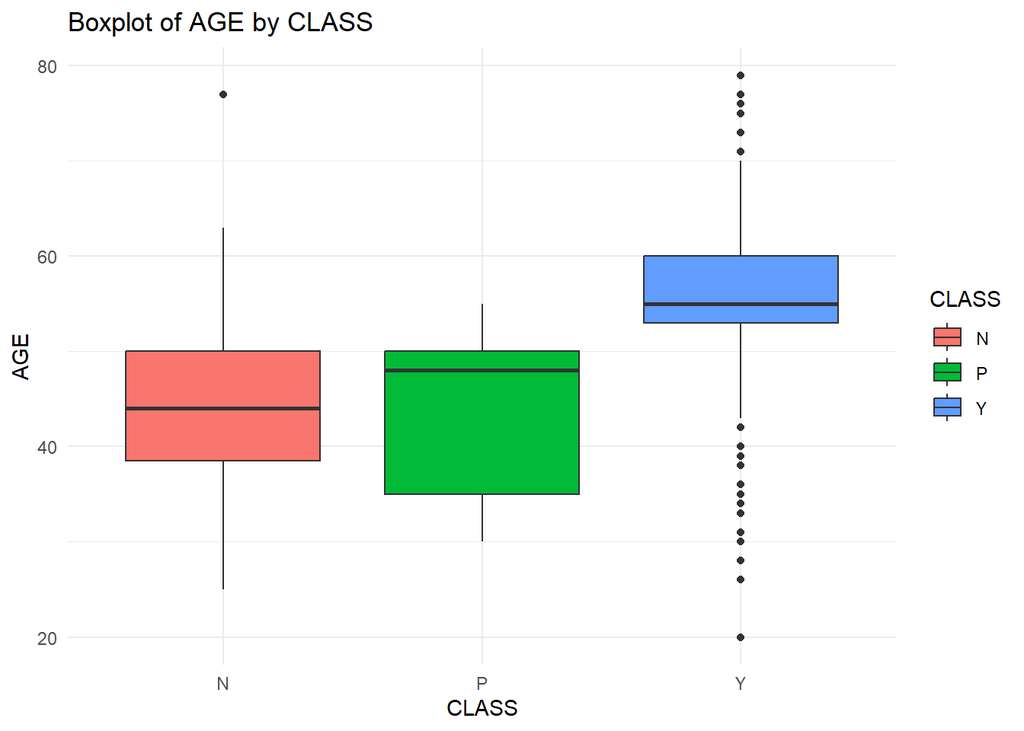

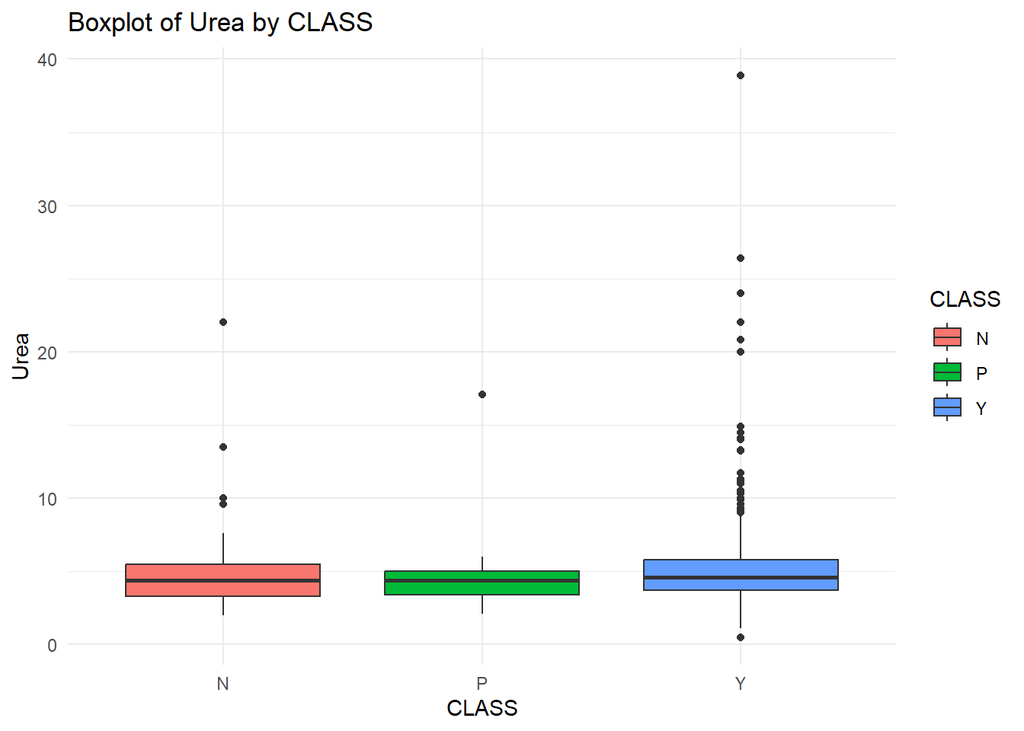

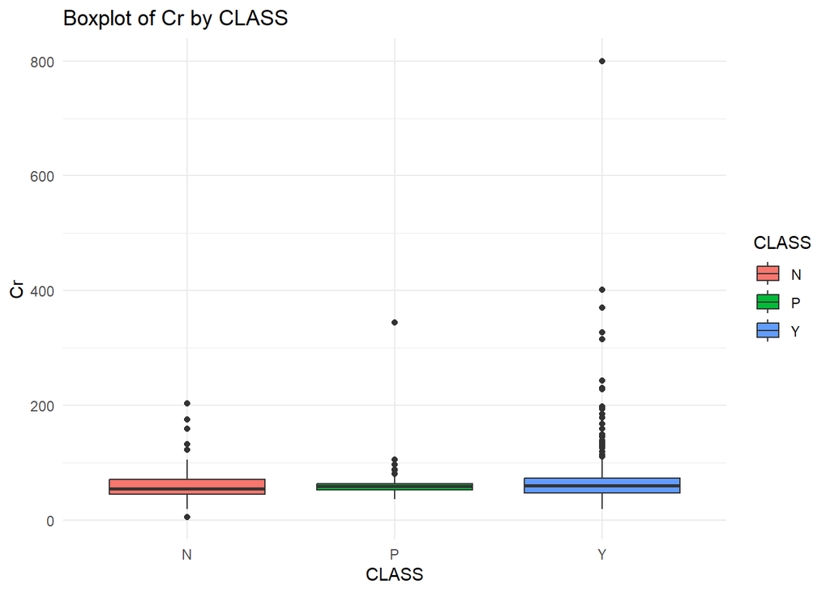

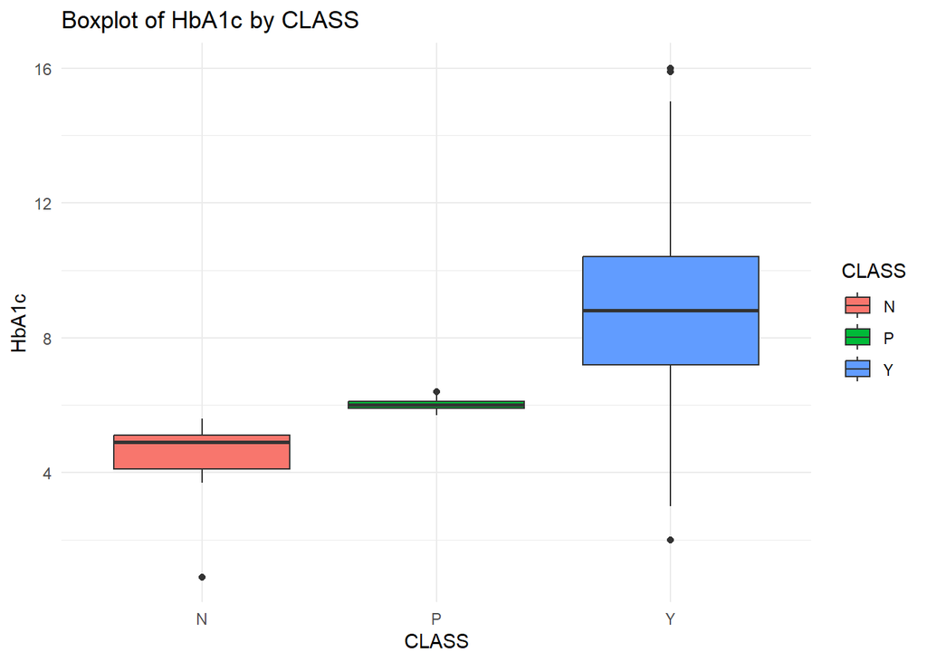

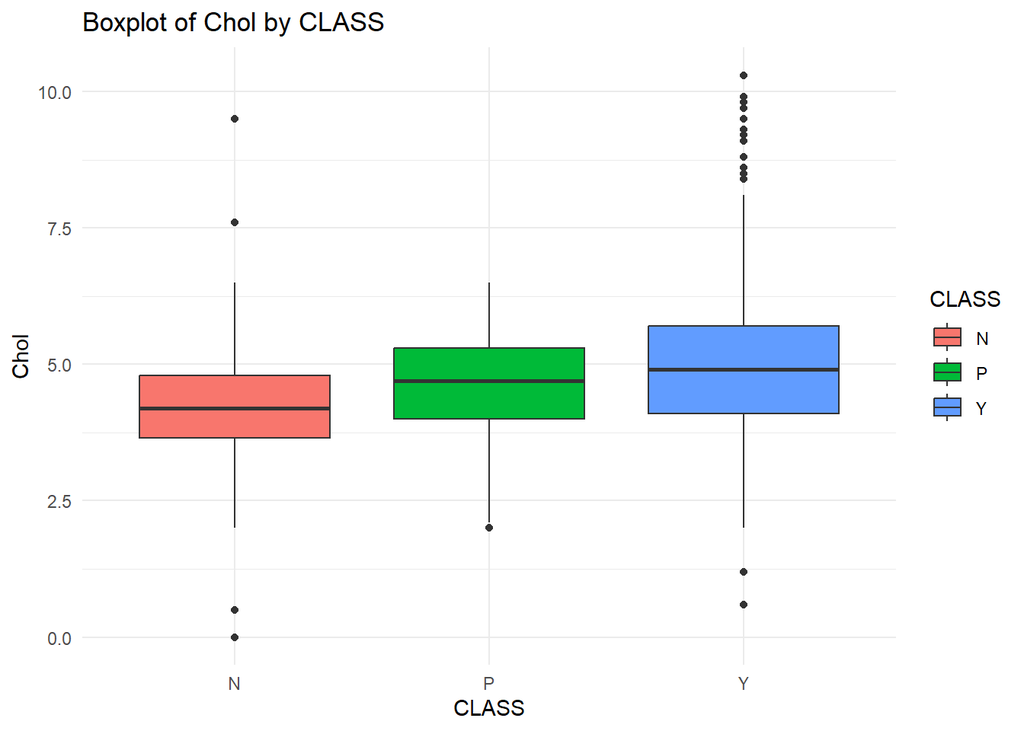

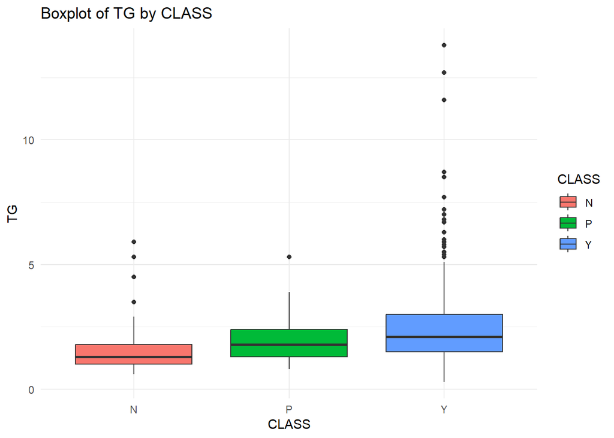

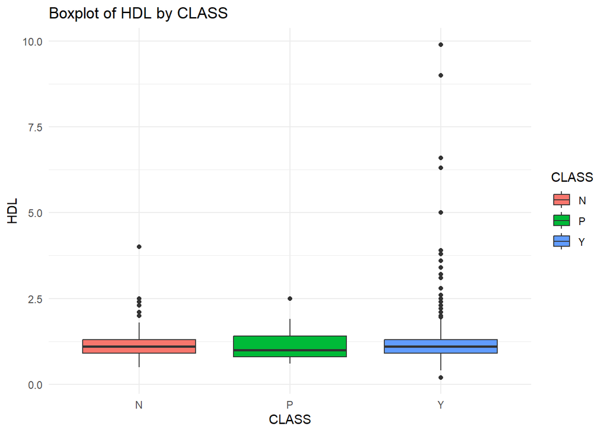

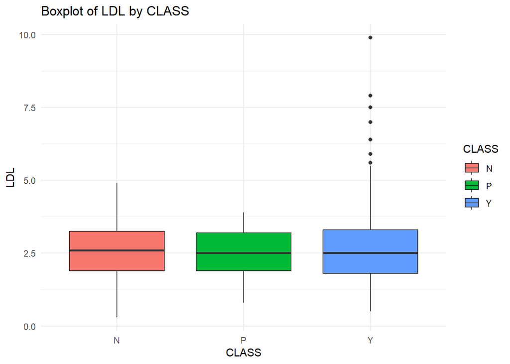

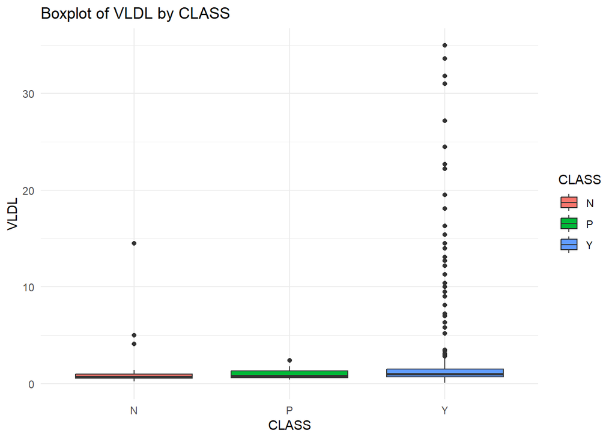

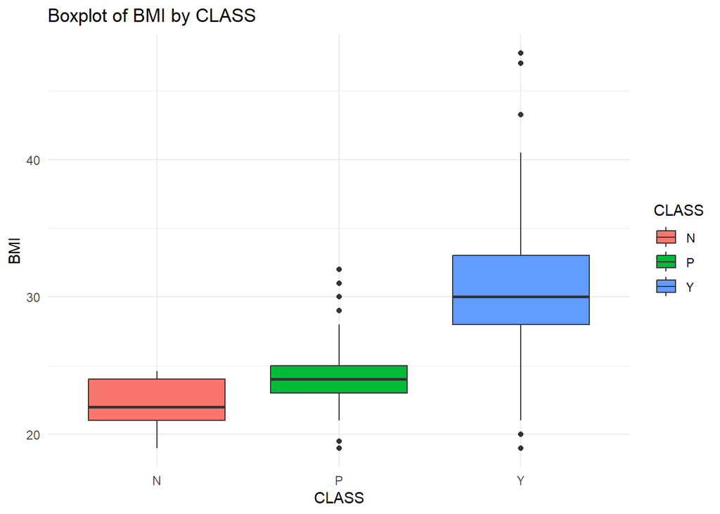

```r
# Function to create boxplots
# Create a copy of the dataset for visualization
diabetes_visualization <- diabetes

# Convert CLASS to a factor with specific levels order
diabetes_visualization$CLASS <- factor(diabetes_visualization$CLASS, levels = c("N", "P", "Y"))
create_boxplot <- function(variable) {
  ggplot(diabetes, aes(x = CLASS, y = !!sym(variable), fill = CLASS)) +
    geom_boxplot() +
    labs(title = paste("Boxplot of", variable, "by CLASS")) +
    theme_minimal()
}

# Function to create density plots
create_density_plot <- function(variable) {
  ggplot(diabetes_visualization, aes(x = !!sym(variable), fill = CLASS)) +
    geom_density(alpha = 0.5) +
    labs(title = paste("Density Plot of", variable, "by CLASS")) +
    theme_minimal()
}

# List of numerical variables for visualization
numerical_variables <- c("AGE", "Urea", "Cr", "HbA1c", "Chol", "TG", "HDL", "LDL", "VLDL", "BMI")

# Create and display boxplots
boxplot_list <- lapply(numerical_variables, create_boxplot)
boxplot_list
```

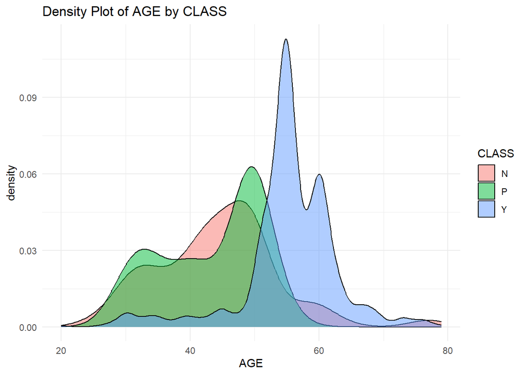

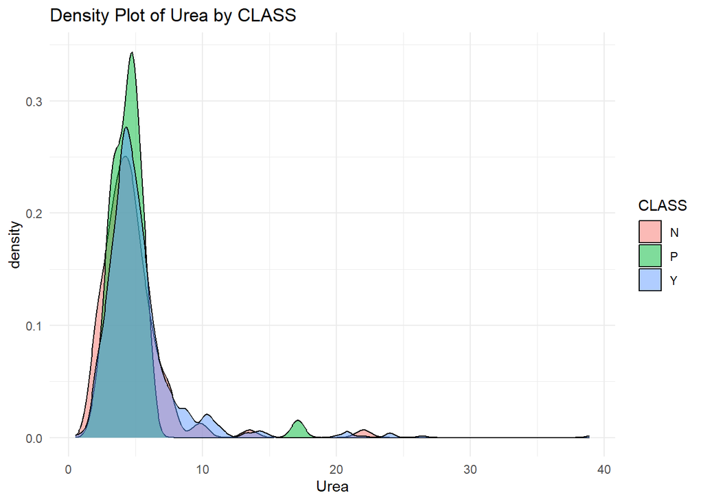

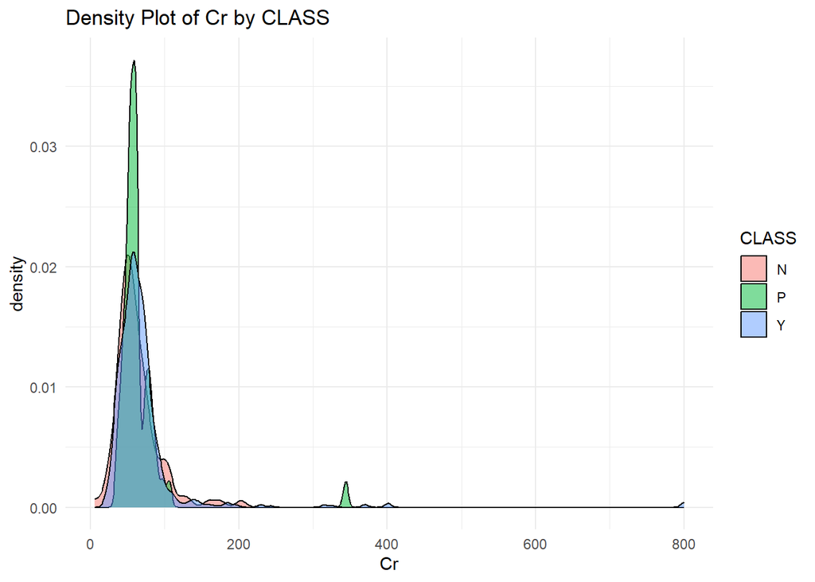

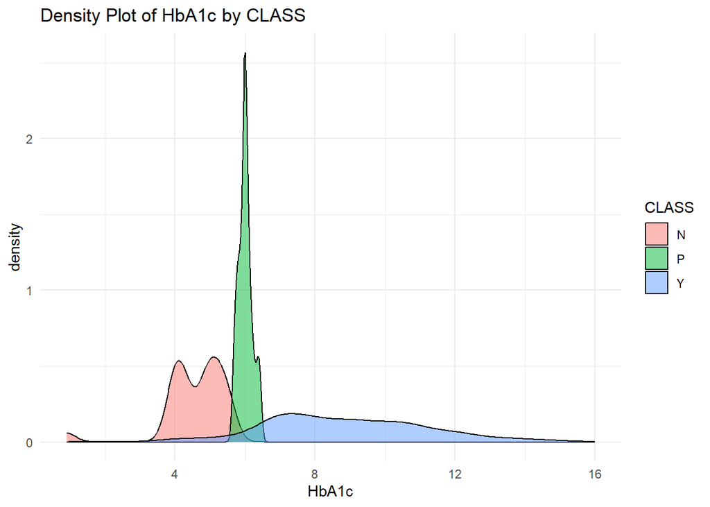

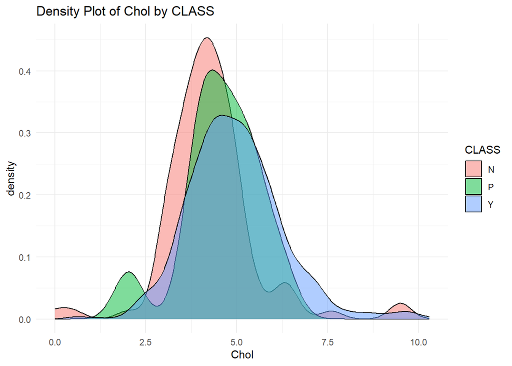

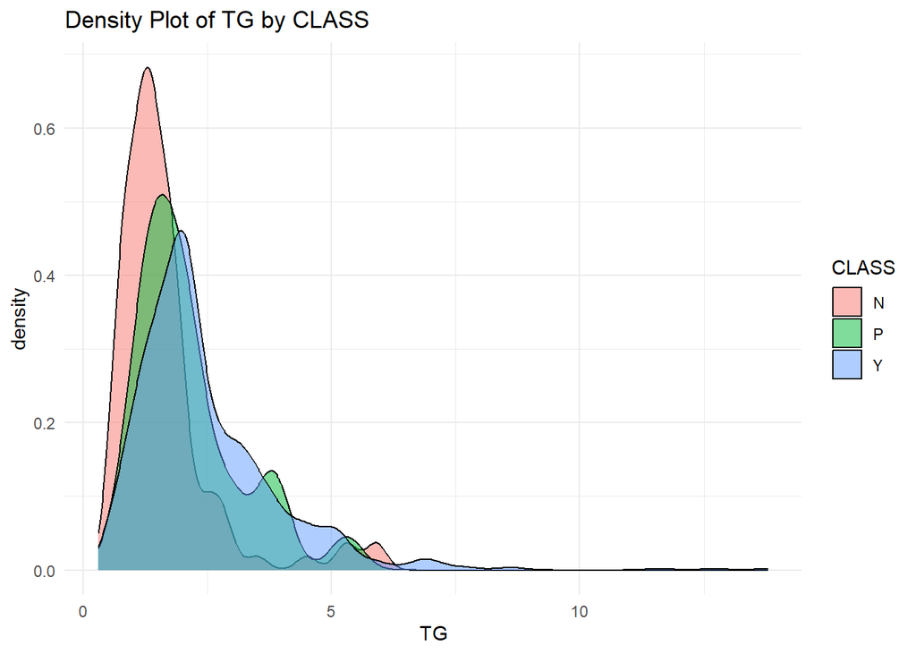

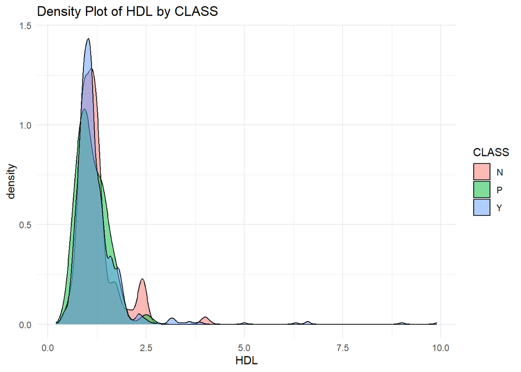

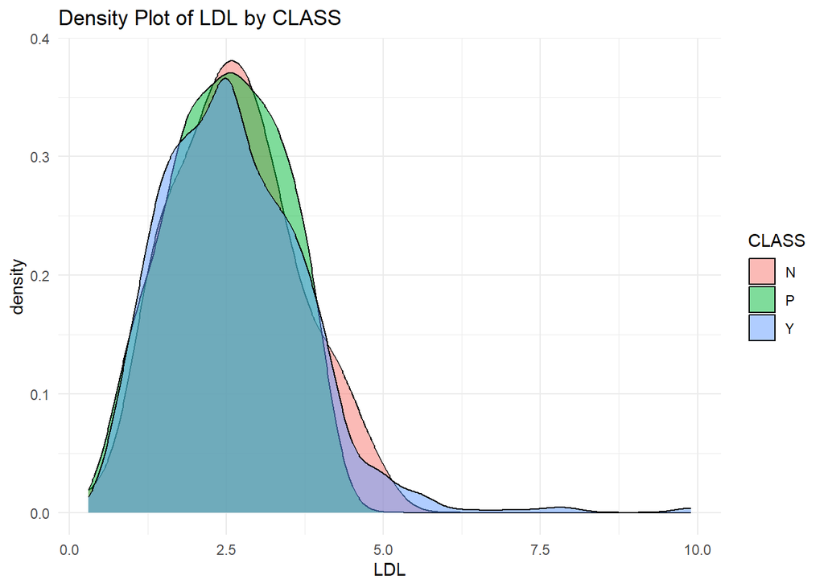

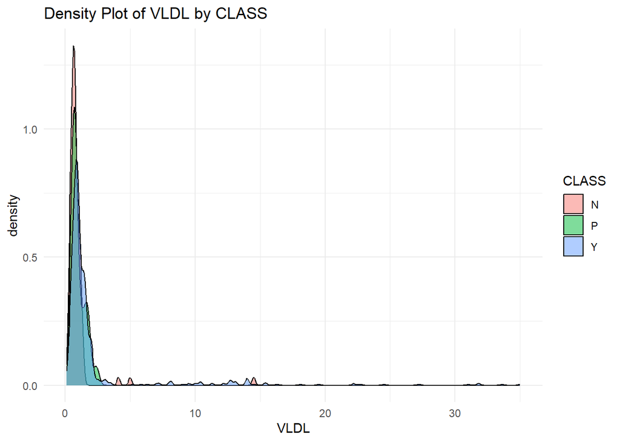

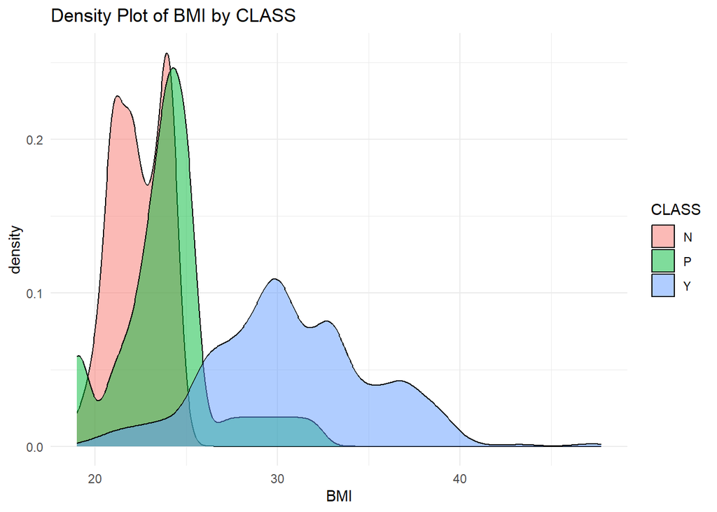

```r
# Create and display density plots
density_plot_list <- lapply(numerical_variables, create_density_plot)
density_plot_list
```

Divide dataset into training(80%) and testing (20%)

```r
set.seed(42)
train_indices <- sample(1:nrow(diabetes), 0.8 * nrow(diabetes))
train_data <- diabetes[train_indices, ]
test_data <- diabetes[-train_indices, ]
```

Research Question 1 1) a) How do various factors contribute to the likelihood of patients being diagnosed with diabetes, as indicated by the ‘CLASS’ variable. b) Identify and analyze the most influential features identified by the decision tree model. Assess the comparative effectiveness of a decision tree model against logistic regression in determining the presence or absence of a medical condition.

```r
# Fit multinomial logistic regression model with all variables
full_model <- multinom(CLASS ~ AGE + Gender + BMI + Urea + Cr + HbA1c + Chol + TG + HDL + LDL + VLDL, data = train_data)
# Summary of the model
summary(full_model)
```

```
## Call:
## multinom(formula = CLASS ~ AGE + Gender + BMI + Urea + Cr + HbA1c +
##     Chol + TG + HDL + LDL + VLDL, data = train_data)
##
## Coefficients:
##   (Intercept)         AGE   Gender       BMI         Urea          Cr    HbA1c
## P   -21.11351 -0.02605882 1.266894 0.4521690 -0.122871294 0.003211243 1.635962
## Y   -44.22180  0.04699452 0.732504 0.9131893  0.000953907 0.002698984 2.253508
##        Chol        TG        HDL        LDL       VLDL
## P 0.4552685 0.6859771 0.08709528 -0.3660598 -0.1829501
## Y 1.0870918 0.7932568 0.24764479  0.1965272  0.1233282
##
## Std. Errors:
##   (Intercept)        AGE    Gender       BMI      Urea          Cr     HbA1c
## P    4.766604 0.02961927 0.5527453 0.1451605 0.1428659 0.009847796 0.3286852
## Y    5.523753 0.03048132 0.5896579 0.1556562 0.1592898 0.010993382 0.3400208
##        Chol        TG       HDL       LDL      VLDL
## P 0.2759726 0.2719025 0.5318567 0.3205775 0.3168279
## Y 0.2897455 0.2899790 0.6671583 0.3281228 0.3096093
##
## Residual Deviance: 259.4241
## AIC: 307.4241
```

```r
# Assuming you have a testing dataset named "test_data"
# Replace "CLASS" with the actual response variable name

# Predict values on the testing dataset
logistic_full_model_prediction <- predict(full_model, newdata = test_data, type = "class")

#Connfusion Matrix and Accuracy of the model
confusionMatrix(logistic_full_model_prediction,test_data$CLASS)
```

```
## Confusion Matrix and Statistics
##
##           Reference
## Prediction   N   P   Y
##          N  16   2   8
##          P   0   4   2
##          Y   0   3 165
##
## Overall Statistics
##
##                Accuracy : 0.925
##                  95% CI : (0.8793, 0.9574)
##     No Information Rate : 0.875
##     P-Value [Acc > NIR] : 0.01637
##
##                   Kappa : 0.7038
##
##  Mcnemar's Test P-Value : 0.01694
##
## Statistics by Class:
##
##                      Class: N Class: P Class: Y
## Sensitivity            1.0000   0.4444   0.9429
## Specificity            0.9457   0.9895   0.8800
## Pos Pred Value         0.6154   0.6667   0.9821
## Neg Pred Value         1.0000   0.9742   0.6875
## Prevalence             0.0800   0.0450   0.8750
## Detection Rate         0.0800   0.0200   0.8250
## Detection Prevalence   0.1300   0.0300   0.8400
## Balanced Accuracy      0.9728   0.7170   0.9114
```

selecting best subset by using stepwise selection and checking the model accuracy

```r
# Variable selection using stepwise selection
stepwise_model <- step(full_model, direction = "both", trace = 0)
```

[output not shown]

```r
# Summary of the stepwise model
summary(stepwise_model)
```

```
## Call:
## multinom(formula = CLASS ~ AGE + Gender + BMI + HbA1c + Chol +
##     TG + LDL + VLDL, data = train_data)
##
## Coefficients:
##   (Intercept)         AGE    Gender       BMI    HbA1c      Chol        TG
## P   -21.16174 -0.02571233 1.1801140 0.4474288 1.608831 0.4690297 0.6718180
## Y   -43.39863  0.04701047 0.7297656 0.9034049 2.246052 1.0751776 0.7806315
##          LDL       VLDL
## P -0.3593638 -0.1657575
## Y  0.1958714  0.1124938
##
## Std. Errors:
##   (Intercept)        AGE    Gender       BMI     HbA1c      Chol        TG
## P    4.560205 0.02925444 0.5171667 0.1426622 0.3190284 0.2704868 0.2677504
## Y    5.265610 0.03019676 0.5589079 0.1528250 0.3334375 0.2819974 0.2774924
##         LDL      VLDL
## P 0.3067277 0.3166076
## Y 0.3136195 0.3102269
##
## Residual Deviance: 261.5424
## AIC: 297.5424
```

```r
# Assuming you have a testing dataset named "test_data"
# Replace "CLASS" with the actual response variable name

# Predict values on the testing dataset using the stepwise model
predictions_stepwise <- predict(stepwise_model, newdata = test_data, type = "class")

confusionMatrix(predictions_stepwise,test_data$CLASS)
```

```
## Confusion Matrix and Statistics
##
##           Reference
## Prediction   N   P   Y
##          N  16   2   8
##          P   0   4   3
##          Y   0   3 164
##
## Overall Statistics
##
##                Accuracy : 0.92
##                  95% CI : (0.8733, 0.9536)
##     No Information Rate : 0.875
##     P-Value [Acc > NIR] : 0.02920
##
##                   Kappa : 0.6892
##
##  Mcnemar's Test P-Value : 0.01857
##
## Statistics by Class:
##
##                      Class: N Class: P Class: Y
## Sensitivity            1.0000   0.4444   0.9371
## Specificity            0.9457   0.9843   0.8800
## Pos Pred Value         0.6154   0.5714   0.9820
## Neg Pred Value         1.0000   0.9741   0.6667
## Prevalence             0.0800   0.0450   0.8750
## Detection Rate         0.0800   0.0200   0.8200
## Detection Prevalence   0.1300   0.0350   0.8350
## Balanced Accuracy      0.9728   0.7144   0.9086
```

```r
diabetes_standardized <- diabetes

numeric_vars <- c("AGE", "Gender","Urea", "Cr", "HbA1c", "Chol", "TG", "HDL", "LDL", "VLDL", "BMI")
diabetes_standardized[, numeric_vars] <- scale(diabetes[, numeric_vars])
#Fit multinomial logistic regression model with all variables
stand_model <- multinom(CLASS ~ ., data = diabetes_standardized)
summary(stand_model)
```

```
## Call:
## multinom(formula = CLASS ~ ., data = diabetes_standardized)
##
## Coefficients:
##   (Intercept)        AGE    Gender       Urea         Cr    HbA1c      Chol
## P     7.72543 -0.3214733 0.6685505 -0.3933116 0.16156264 4.087762 0.7218949
## Y    13.03656  0.3551004 0.3043996  0.2167456 0.05904294 5.361373 1.5402516
##         TG        HDL         LDL       VLDL      BMI
## P 1.012212 -0.1069686 -0.34365905 -0.6877477 2.548514
## Y 1.068861  0.2595912  0.05532626  0.6572182 4.667515
##
## Std. Errors:
##   (Intercept)       AGE    Gender      Urea        Cr     HbA1c      Chol
## P    1.546180 0.2508357 0.2494830 0.4019273 0.5700027 0.7441294 0.3641660
## Y    1.576611 0.2529600 0.2560557 0.3719662 0.5653523 0.7544768 0.3811599
##          TG       HDL       LDL      VLDL       BMI
## P 0.3681030 0.3283651 0.3359830 0.9299810 0.6365346
## Y 0.3859335 0.3397312 0.3431554 0.8021876 0.6765862
##
## Residual Deviance: 331.1592
## AIC: 379.1592
```

```r
predictions_standardized_model <- predict(stand_model, newdata = test_data, type = "class")

confusionMatrix(predictions_standardized_model,test_data$CLASS)
```

```
## Confusion Matrix and Statistics
##
##           Reference
## Prediction   N   P   Y
##          N   0   0   0
##          P   0   0   0
##          Y  16   9 175
##
## Overall Statistics
##
##                Accuracy : 0.875
##                  95% CI : (0.821, 0.9174)
##     No Information Rate : 0.875
##     P-Value [Acc > NIR] : 0.553
##
##                   Kappa : 0
##
##  Mcnemar's Test P-Value : NA
##
## Statistics by Class:
##
##                      Class: N Class: P Class: Y
## Sensitivity              0.00    0.000    1.000
## Specificity              1.00    1.000    0.000
## Pos Pred Value            NaN      NaN    0.875
## Neg Pred Value           0.92    0.955      NaN
## Prevalence               0.08    0.045    0.875
## Detection Rate           0.00    0.000    0.875
## Detection Prevalence     0.00    0.000    1.000
## Balanced Accuracy        0.50    0.500    0.500
```

Now lets Build tree models for the dataset.

```r
# Assuming you have a training dataset named "train_data"
# Replace "CLASS" with the actual response variable name
# Fit a decision tree model
tree_model <- rpart(CLASS ~ ., data = train_data, method = "class")
summary(tree_model)
```

```
## Call:
## rpart(formula = CLASS ~ ., data = train_data, method = "class")
##   n= 800
##
##           CP nsplit  rel error    xerror       xstd
## 1 0.29007634      0 1.00000000 1.0000000 0.07989736
## 2 0.28244275      1 0.70992366 0.9083969 0.07682998
## 3 0.13740458      2 0.42748092 0.4122137 0.05416890
## 4 0.09923664      3 0.29007634 0.2442748 0.04230964
## 5 0.05343511      4 0.19083969 0.2061069 0.03899019
## 6 0.02671756      6 0.08396947 0.1450382 0.03287653
## 7 0.01000000      8 0.03053435 0.1450382 0.03287653
##
## Variable importance
##  HbA1c    BMI    AGE   Chol     TG    LDL   VLDL     Cr    HDL Gender
##     36     28     18      5      3      3      3      2      1      1
##
## Node number 1: 800 observations,    complexity param=0.2900763
##   predicted class=Y  expected loss=0.16375  P(node) =1
##     class counts:    87    44   669
##    probabilities: 0.109 0.055 0.836
##   left son=2 (173 obs) right son=3 (627 obs)
##   Primary splits:
##       HbA1c < 6.15  to the left,  improve=107.36720, (0 missing)
##       BMI   < 25.3  to the left,  improve=107.00630, (0 missing)
##       AGE   < 50.5  to the left,  improve= 77.58838, (0 missing)
##       TG    < 1.905 to the left,  improve= 12.23929, (0 missing)
##       VLDL  < 0.85  to the left,  improve= 11.70960, (0 missing)
##   Surrogate splits:
##       BMI  < 25.3  to the left,  agree=0.921, adj=0.636, (0 split)
##       AGE  < 50.5  to the left,  agree=0.877, adj=0.434, (0 split)
##       Chol < 1.3   to the left,  agree=0.789, adj=0.023, (0 split)
##
## Node number 2: 173 observations,    complexity param=0.2824427
##   predicted class=N  expected loss=0.4971098  P(node) =0.21625
##     class counts:    87    37    49
##    probabilities: 0.503 0.214 0.283
##   left son=4 (121 obs) right son=5 (52 obs)
##   Primary splits:
##       HbA1c < 5.65  to the left,  improve=37.217930, (0 missing)
```

[output cut: 137 more lines]

```
##       VLDL   < 0.85  to the left,  agree=0.900, adj=0.786, (0 split)
##       Cr     < 55    to the left,  agree=0.700, adj=0.357, (0 split)
##       HbA1c  < 4.05  to the right, agree=0.700, adj=0.357, (0 split)
##       HDL    < 1.05  to the right, agree=0.700, adj=0.357, (0 split)
##       Gender < 0.5   to the left,  agree=0.667, adj=0.286, (0 split)
##
## Node number 34: 16 observations
##   predicted class=N  expected loss=0.125  P(node) =0.02
##     class counts:    14     0     2
##    probabilities: 0.875 0.000 0.125
##
## Node number 35: 14 observations
##   predicted class=Y  expected loss=0  P(node) =0.0175
##     class counts:     0     0    14
##    probabilities: 0.000 0.000 1.000
```

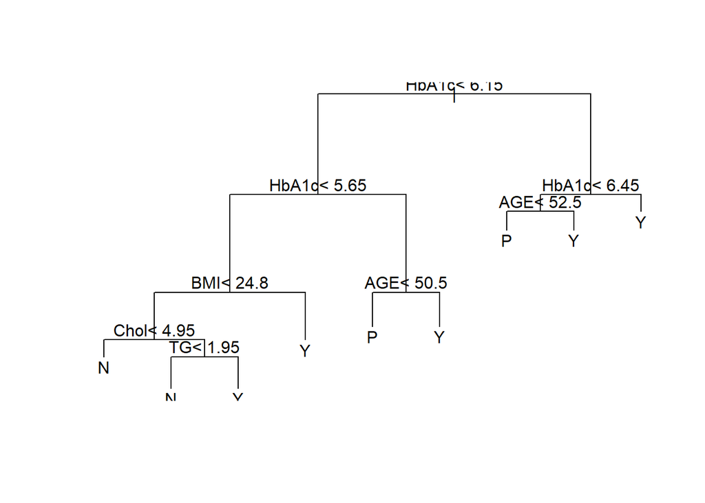

```r
plot(tree_model)
text(tree_model,pretty=0)
```

Pruning the tree and checking the accuracy

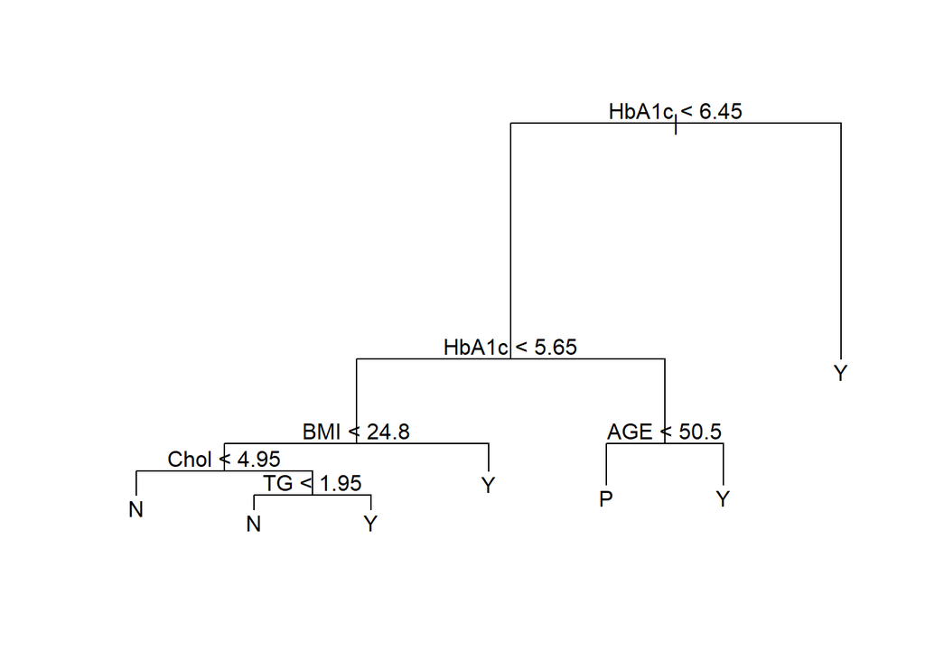

```r
# Fit an unpruned decision tree model
unpruned_tree <- tree(CLASS ~ ., data = train_data)

# Visualize the unpruned decision tree
plot(unpruned_tree)
text(unpruned_tree)
```

```r
# Assess the performance of the unpruned tree on the testing dataset
# Replace "test_data" with your actual testing dataset
predictions_unpruned <- predict(unpruned_tree, newdata = test_data, type = "class")

confusionMatrix(predictions_unpruned,test_data$CLASS)
```

```
## Confusion Matrix and Statistics
##
##           Reference
## Prediction   N   P   Y
##          N  16   0   3
##          P   0   9   0
##          Y   0   0 172
##
## Overall Statistics
##
##                Accuracy : 0.985
##                  95% CI : (0.9568, 0.9969)
##     No Information Rate : 0.875
##     P-Value [Acc > NIR] : 1.075e-08
##
##                   Kappa : 0.9369
##
##  Mcnemar's Test P-Value : NA
##
## Statistics by Class:
##
##                      Class: N Class: P Class: Y
## Sensitivity            1.0000    1.000   0.9829
## Specificity            0.9837    1.000   1.0000
## Pos Pred Value         0.8421    1.000   1.0000
## Neg Pred Value         1.0000    1.000   0.8929
## Prevalence             0.0800    0.045   0.8750
## Detection Rate         0.0800    0.045   0.8600
## Detection Prevalence   0.0950    0.045   0.8600
## Balanced Accuracy      0.9918    1.000   0.9914
```

Pruned tree model with 4

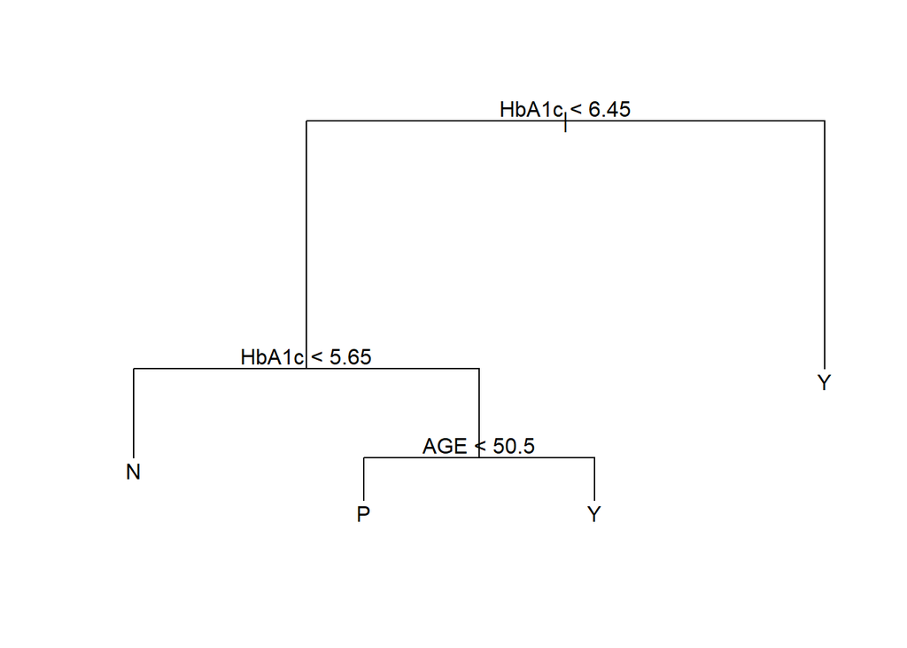

```r
# Prune the decision tree
pruned_tree <- prune.tree(unpruned_tree, best = 4)
plot(pruned_tree)
text(pruned_tree)
```

```r
predictions_pruned <- predict(pruned_tree, newdata = test_data, type = "class")

confusionMatrix(predictions_pruned,test_data$CLASS)
```

```
## Confusion Matrix and Statistics
##
##           Reference
## Prediction   N   P   Y
##          N  16   0  12
##          P   0   9   0
##          Y   0   0 163
##
## Overall Statistics
##
##                Accuracy : 0.94
##                  95% CI : (0.8975, 0.9686)
##     No Information Rate : 0.875
##     P-Value [Acc > NIR] : 0.001914
##
##                   Kappa : 0.7807
##
##  Mcnemar's Test P-Value : NA
##
## Statistics by Class:
##
##                      Class: N Class: P Class: Y
## Sensitivity            1.0000    1.000   0.9314
## Specificity            0.9348    1.000   1.0000
## Pos Pred Value         0.5714    1.000   1.0000
## Neg Pred Value         1.0000    1.000   0.6757
## Prevalence             0.0800    0.045   0.8750
## Detection Rate         0.0800    0.045   0.8150
## Detection Prevalence   0.1400    0.045   0.8150
## Balanced Accuracy      0.9674    1.000   0.9657
```

Research Question 2 What is the relationship between hbA1c levels and various factors, and how well can hbA1c be predicted using regression models? Additionally, can hierarchical clustering provide insights into the patterns of correlation among hbA1c and other variables.

```r
library(lmtest)
```

```r
library(corrplot)
library(glmnet)
library(ggplot2)
```

Ridge Regression

```r
# checking data types
sapply(diabetes[, names(diabetes) != "HbA1c"], class)
```

```
##       AGE    Gender      Urea        Cr      Chol        TG       HDL       LDL
## "integer" "numeric" "numeric" "integer" "numeric" "numeric" "numeric" "numeric"
##      VLDL       BMI     CLASS
## "numeric" "numeric"  "factor"
```

```r
# Ridge Regression
ridge_model <- cv.glmnet(as.matrix(diabetes[, names(diabetes) != "HbA1c"]), diabetes$HbA1c, alpha = 0)
ridge_predictions <- predict(ridge_model, newx = as.matrix(diabetes[, names(diabetes) != "HbA1c"]))
ridge_mse <- mean((ridge_predictions - diabetes$HbA1c)^2)
ridge_mse
```

```
## [1] 4.890947
```

```r
# Lasso Regression
lasso_model <- cv.glmnet(as.matrix(diabetes[, names(diabetes) != "HbA1c"]), diabetes$HbA1c, alpha = 1)
lasso_predictions <- predict(lasso_model, newx = as.matrix(diabetes[, names(diabetes) != "HbA1c"]))
```

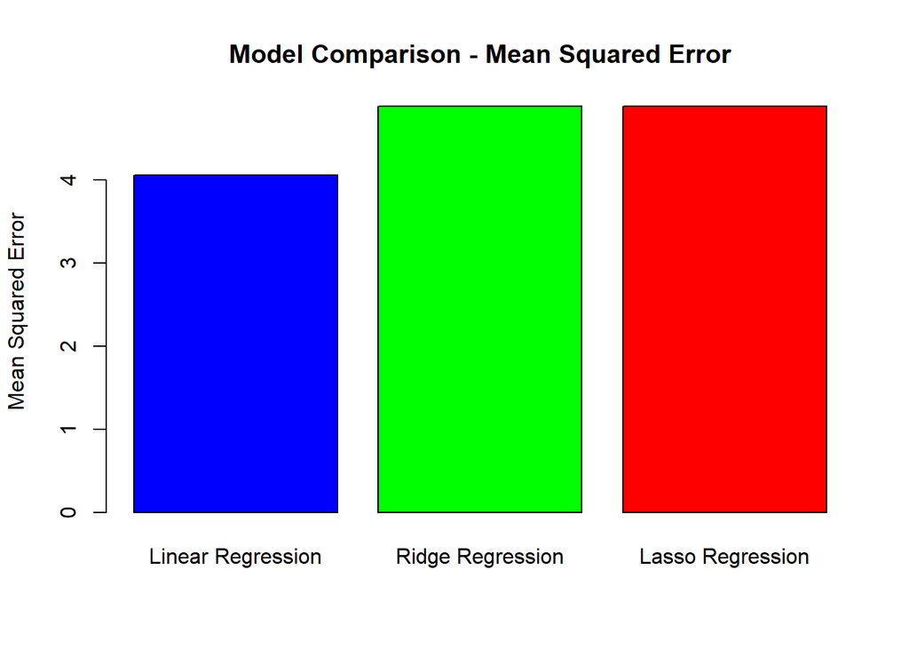

```r
lasso_mse <- mean((lasso_predictions - diabetes$HbA1c)^2)

# Regression Analysis
lm_model <- lm(HbA1c ~ ., data = diabetes)
lm_predictions <- predict(lm_model, newdata = diabetes)
lm_mse <- mean((lm_predictions - diabetes$HbA1c)^2)

# Evaluate Models
# Create a bar plot
model_names <- c("Linear Regression", "Ridge Regression", "Lasso Regression")
mse_values <- c(lm_mse, ridge_mse, lasso_mse)

barplot(mse_values, names.arg = model_names, col = c("blue", "green", "red"),
        main = "Model Comparison - Mean Squared Error",
        ylab = "Mean Squared Error")
```

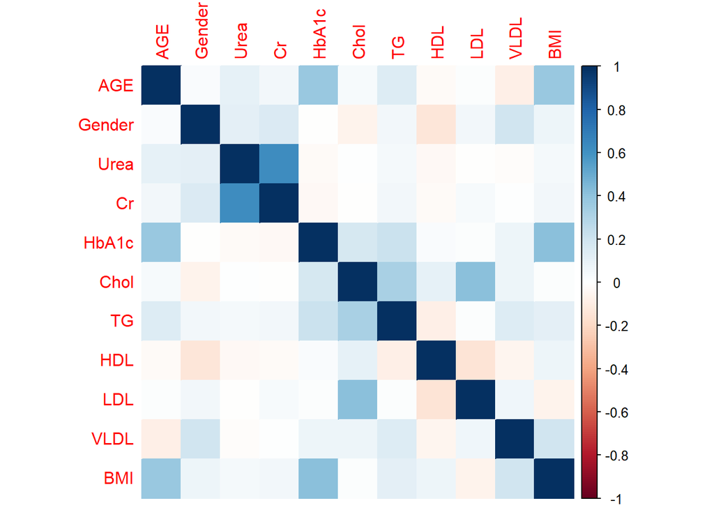

```r
# Correlation Analysis
numeric_diabetes <- diabetes[, sapply(diabetes, is.numeric)]
cor_matrix <- cor(numeric_diabetes)
corrplot(cor_matrix, method = "color")
```

```r
# Hierarchical Clustering
hc_result <- hclust(dist(diabetes),method="complete")
```

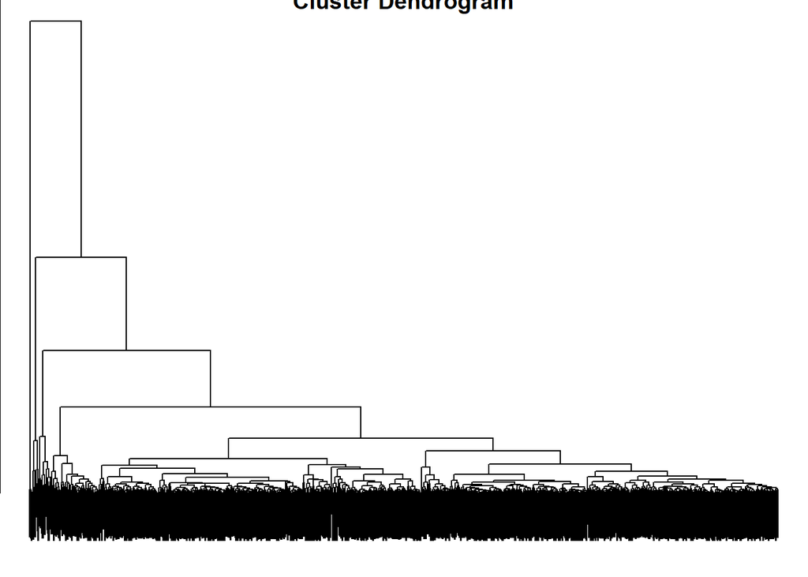

```r
par(mar = c(0, 0, 0, 0))
# Creating hierarchical clustering plot without labels
plot(hc_result, labels = FALSE)
```

Research Question 3 3Q) H0: There is no relationship between AGE and BMI versus the alternative hypothesis Ha: There is some relationship between AGE and BMI Test: Trying to find out the correlation between AGE and BMI and plot the relation.

```r
cor(diabetes$AGE,diabetes$BMI)
```

```
## [1] 0.375956
```

```r
fit = lm(AGE~BMI, data=diabetes);
summary(fit)
```

```
##
## Call:
## lm(formula = AGE ~ BMI, data = diabetes)
##
## Residuals:
##     Min      1Q  Median      3Q     Max
## -33.809  -3.276   0.524   4.191  30.524
##
## Coefficients:
##             Estimate Std. Error t value Pr(>|t|)
## (Intercept) 33.81010    1.55988   21.68   <2e-16 ***
## BMI          0.66664    0.05201   12.82   <2e-16 ***
## ---
## Signif. codes:  0 '***' 0.001 '**' 0.01 '*' 0.05 '.' 0.1 ' ' 1
##
## Residual standard error: 8.158 on 998 degrees of freedom
## Multiple R-squared:  0.1413, Adjusted R-squared:  0.1405
## F-statistic: 164.3 on 1 and 998 DF,  p-value: < 2.2e-16
```

```r
confint(fit)
```

```
##                  2.5 %     97.5 %
## (Intercept) 30.7490908 36.8711160
## BMI          0.5645758  0.7687046
```

```r
confint(fit, level =0.99 )
```

```
##                  0.5 %     99.5 %
## (Intercept) 29.7844312 37.8357755
## BMI          0.5324108  0.8008695
```

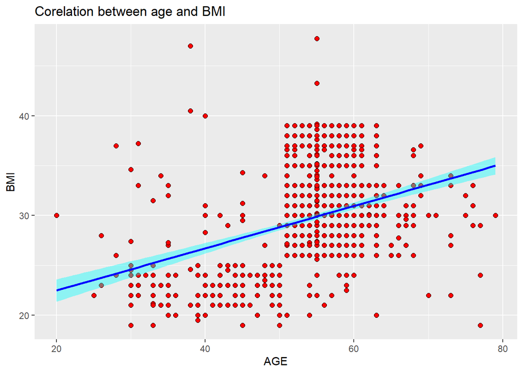

```r
(ggplot(diabetes,aes(x = AGE,y = BMI)) +
    geom_point(shape = 21,fill = "red",
               color = "black",size = 2) +
    stat_smooth(method = lm,
                color = "blue",fill = "cyan") +
    labs(
      x = "AGE",
      y = "BMI",
      title = "Corelation between age and BMI"))
```

Interpretation: There exits a correlation between AGE and BMI.